# ggplot2

## 4.7 Another perspective with dotplots (Vertical bins)

> What if we want to compare the distribution of Infection (No vs Yes) side by side ? We will need to map the infection variable to the x axis and move the age variable to the y axis. We’ll also keep the infection variable with the `fill` argument that way a separate color will be used for infection = No and infection = Yes

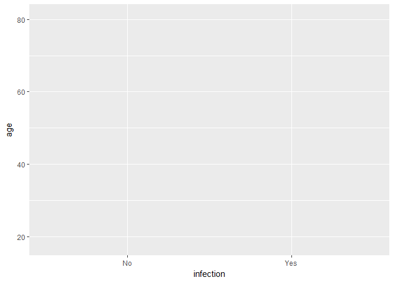

```r
ggplot(df, aes(y = age, x = infection, fill = infection))
```

> Now we have the basis of the plot, we can add the dotplot geom once again, except we’ll bin the histodots on the y axis instead of x and keep the stack them aligned to the center. We can do this using the `binaxis` argument specifying it on the y axis and we want the stacks within the center

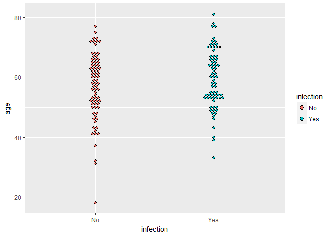

```r
ggplot(df, aes(y = age, x = infection, fill = infection)) +
  geom_dotplot(binaxis = "y", stackdir = "center",
               binwidth = 1, method = "histodot")
```

> Now let’s add some descriptive indicators on the plot via the `stat_summary()` function. Let’s add an indicator of the medians for both the non infection group and the infection group. `stat_summary()` allows us to map a function to the y axis. We will use the `median` function to accomplish this, and use the geom crossbar to visualize the measure.

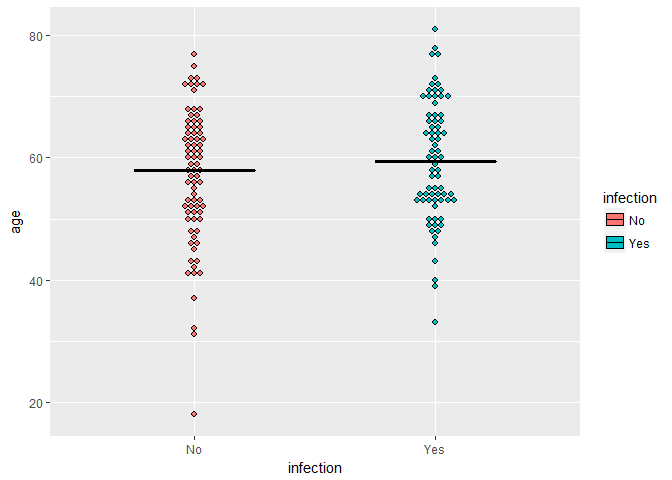

```r
ggplot(df, aes(y = age, x = infection, fill = infection)) +
  geom_dotplot(binaxis = "y", stackdir = "center",
               binwidth = 1, method = "histodot") +
  stat_summary(fun.y = median, fun.ymin = median, fun.ymax = median, geom = "crossbar", width = 0.5)
```

> Let’s finish cleaning up the plot with some of the other functions we have learned

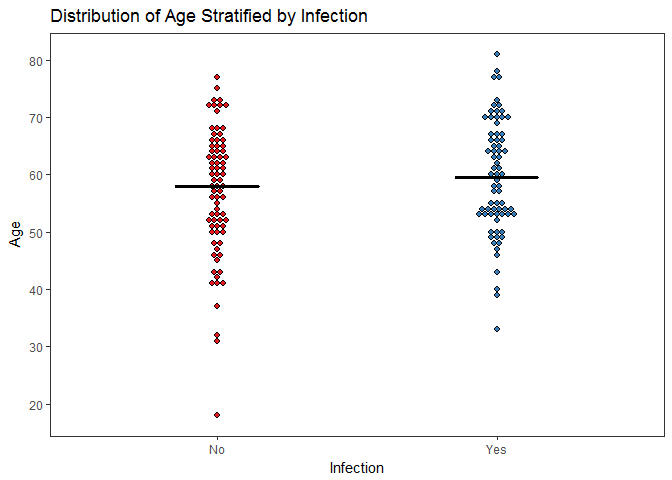

```r
# manually calculate the median age by infection group

ggplot(df, aes(y = age, x = infection, fill = infection)) +
  geom_dotplot(binaxis = "y", stackdir = "center",
               binwidth = 1, method = "histodot") +
  stat_summary(fun.y = median, fun.ymin = median, fun.ymax = median, geom = "crossbar", width = 0.3) +
  theme_bw() +
  theme(legend.position = "none",
        panel.grid = element_blank()) +
  scale_fill_brewer("infection", palette = "Set1") +
  labs(y = "Age", x = "Infection", title = 'Distribution of Age Stratified by Infection') +
  scale_y_continuous(breaks = seq(0,100, 10))
```

# 5 Saving the plot we just made

> Now that we’re happy with the plot we just made, we should save it so we can share it with our collaborators. There are we can do this by invoking the `ggsave()` function. By default `ggsave()` will save the last plot that was rendered, however we can also specify the plot we would like to save as well.

> The command for `ggsave()` is `ggsave(filename = NULL, plot = last_plot(), ...)`. Please see the documentation for further details using `?ggsave`, for other possible arguments to configure.

```r
ggsave('my_first_plot.png', height = 6, width = 8)
```

> This function will save the previous plot, in your project directory as my_first_plot.png, with a height of 6 inches, and a width of 8 inches.

# 6 Histogram plots

> We start off with the same base template of ggplot2, by assigning ggplot2 the 2 initial requirements for a plot. The name of the dataframe and a mapping for the coordinate within the aesthetic.

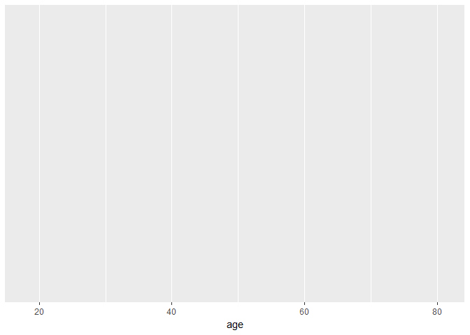

```r
ggplot(df, aes(x = age))
```

> Next we move forward with stating the name of the geom we want to use, let’s try out the histogram geom called `geom_histogram()`. This is the basic foundation for all plots with ggplot2. The initial function `ggplot()` with the addition of visualization geoms we add layer by layer. Please feel free to experiment with additional geoms, however we will probably not have time to go through all of them.

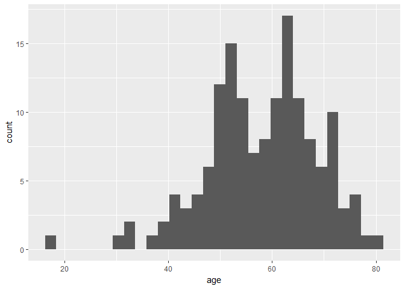

```r
ggplot(df, aes(x = age)) + geom_histogram()
```

> Huzzah! We have a histogram of age, a method of visualizing the distribution of age. Lets follow the same idea of the dotplot by changing the width of the columns of our histogram. `geom_histogram` also has the same argument called `binwidth` which allows us to make that change. `binwidth = 5` allows us to change the width of the bins (columns) to every 5 years of age. We can also better visualize this by changing the scale on the x axis with `scale_x_continuous()`

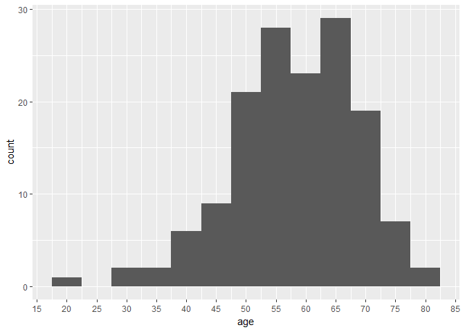

```r
ggplot(df, aes(x = age)) +
  geom_histogram(binwidth = 5) +
  scale_x_continuous(breaks = seq(0,100,5))
```

> Lets add a theme

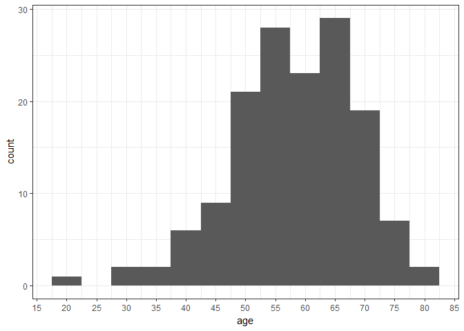

```r
ggplot(df, aes(x = age)) +
  geom_histogram(binwidth = 5) +
  scale_x_continuous(breaks = seq(0,100,5)) +
  theme_bw()
```

> The histogram also has the ability to show the density on the y axis instead of counts. We can do this by specifying the mapping within the `aes()` function by using `y = ..density..`

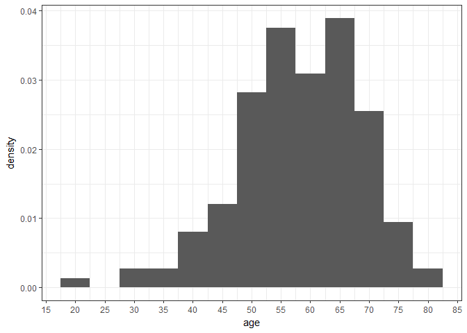

```r
ggplot(df, aes(x = age, y = ..density..)) +
  geom_histogram(binwidth = 5) +
  scale_x_continuous(breaks = seq(0,100,5)) +
  theme_bw()
```

> We can add colors by mapping the fill aesthetic with our variable infection

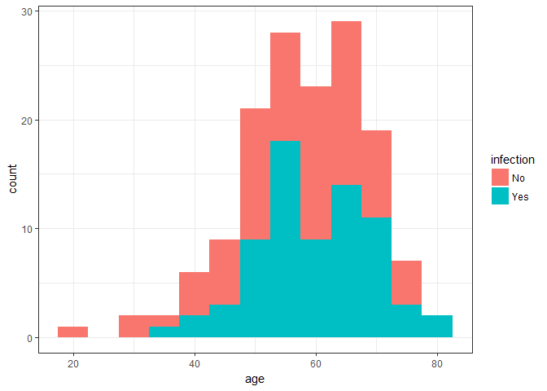

```r
ggplot(df, aes(x = age, fill = infection)) +
  geom_histogram(binwidth = 5) +
  theme_bw()
```

> Changing the axis and scale titles

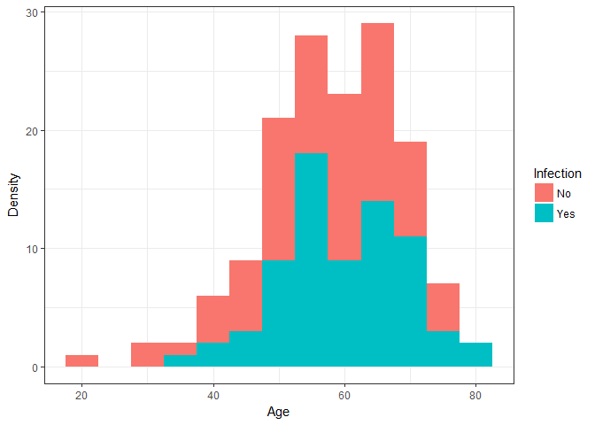

```r
ggplot(df, aes(x = age, fill = infection)) +
  geom_histogram(binwidth = 5)  +
  theme_bw() +
  scale_fill_discrete("Infection") +
  labs(x = "Age", y = "Density")
```

> Changing the colors by utilizing a palette

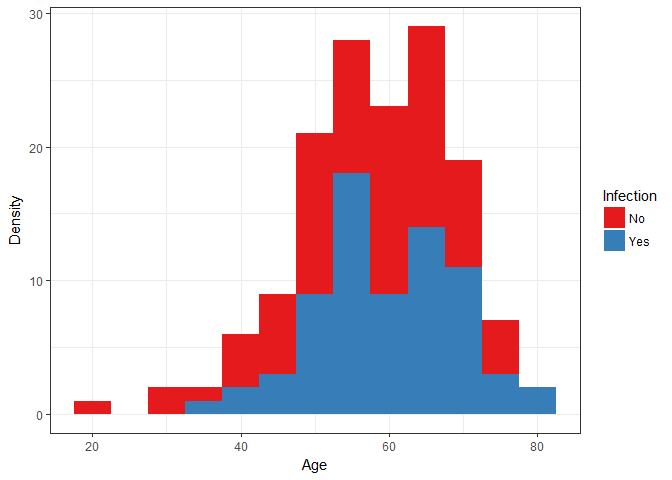

```r
ggplot(df, aes(x = age, fill = infection)) +
  geom_histogram(binwidth = 5)  +
  theme_bw() +
  scale_fill_brewer("Infection", palette = "Set1") +
  labs(x = "Age", y = "Density")
```

> Using different panels or ‘facets’

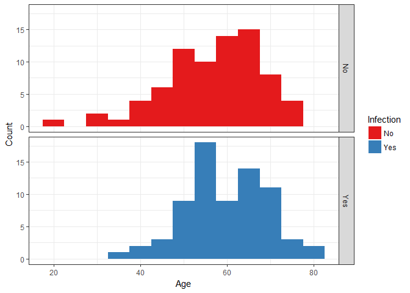

```r
ggplot(df, aes(x = age, fill = infection)) +
  geom_histogram(binwidth = 5)  +
  theme_bw() +
  scale_fill_brewer("Infection", palette = "Set1") +
  labs(x = "Age", y = 'Count') +
  facet_grid(infection ~ .)
```

## 6.1 Removing the legend and adding both the variable name and levels on the facet ‘strips’

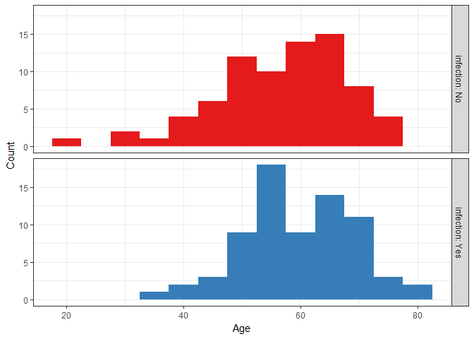

```r
ggplot(df, aes(x = age, fill = infection)) +
  geom_histogram(binwidth = 5)  +
  theme_bw() +
  scale_fill_brewer("infection", palette = "Set1") +
  labs(x = "Age", y = 'Count') +
  facet_grid(infection ~ ., labeller = label_both) +
  theme(legend.position = "none")
```

## 6.2 Let’s add an extra dimension

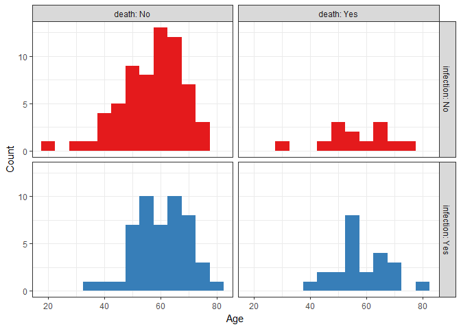

```r
ggplot(df, aes(x = age, fill = infection)) +
  geom_histogram(binwidth = 5)  +
  theme_bw() +
  scale_fill_brewer("infection", palette = "Set1") +
  labs(x = "Age", y = 'Count') +
  facet_grid(infection ~ death, labeller = label_both) +
  theme(legend.position = "none")
```

## 6.3 Let’s add even more dimensions

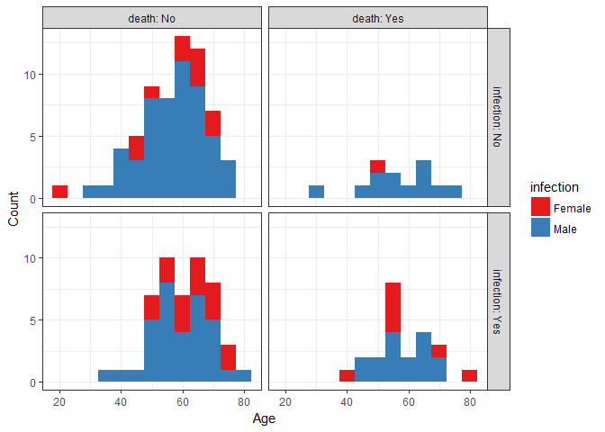

```r
ggplot(df, aes(x = age, fill = gender)) +
  geom_histogram(binwidth = 5)  +
  theme_bw() +
  scale_fill_brewer("infection", palette = "Set1") +
  labs(x = "Age", y = 'Count') +
  facet_grid(infection ~ death, labeller = label_both)
```

## 6.4 Even more dimensions

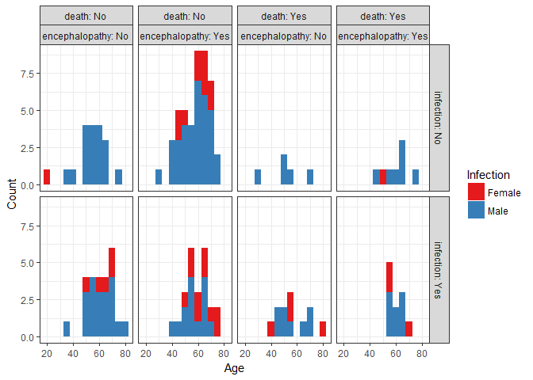

```r
ggplot(df, aes(x = age, fill = gender)) +
  geom_histogram(binwidth = 5)  +
  theme_bw() +
  scale_fill_brewer("Infection", palette = "Set1") +
  labs(x = "Age", y = 'Count') +
  facet_grid(infection ~ death + encephalopathy, labeller = label_both)
```

# 7 Boxplots

> Of note, we need to add the `stat_boxplot()` function before the geom_boxplot. Remember, we are building plots layer by layer. We want the `stat_boxplot()` layer first, so we can overlay the `geom_boxpplot()` function over it the first layer. Experiment with the order of the layers to get the plot to how you want it.

## 7.5 Stratified boxplots by a factor

> We can also add a fill aesthetic by infection to separate the boxplot into no infection and yes infection. To do this we will also need to map the infection variable to the x axis. I’ve also added the fill argument, so we can have separate colors for No and Yes.

> We can further clean up the plot by changing the axis title and legend title

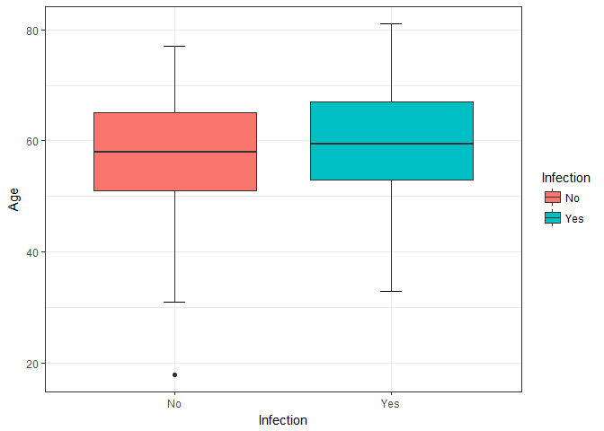

```r
ggplot(df, aes(y = age, x = infection, fill = infection)) +
  stat_boxplot(geom = "errorbar", width = 0.1) +
  geom_boxplot() +
  theme_bw() +
  scale_fill_discrete('Infection') +
  labs(x = "Infection", y = "Age")
```

## 7.6 Change the colors by using a palette

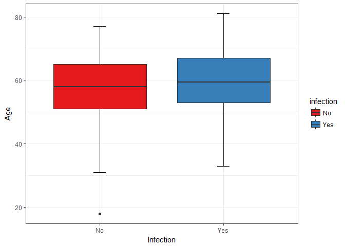

```r
ggplot(df, aes(y = age, x = infection, fill = infection)) +
  stat_boxplot(geom = "errorbar", width = 0.1) +
  geom_boxplot() +
  theme_bw() +
  scale_fill_brewer("infection", palette = "Set1") +
  labs(x = "Infection", y = "Age")
```

## 7.7 Removing the legend within the `theme()` function

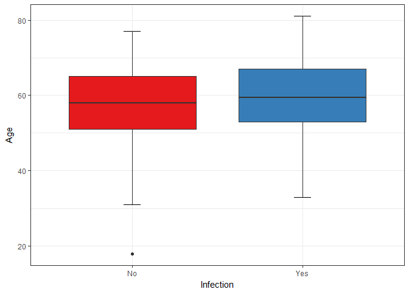

```r
ggplot(df, aes(y = age, x = infection, fill = infection)) +
  stat_boxplot(geom = "errorbar", width = 0.1) +
  geom_boxplot() +
  theme_bw() +
  scale_fill_brewer("infection", palette = "Set1") +
  labs(x = "Infection", y = "Age") +
  theme(legend.position = "none")
```

## 7.8 Overlaying an additional geom (scatter)

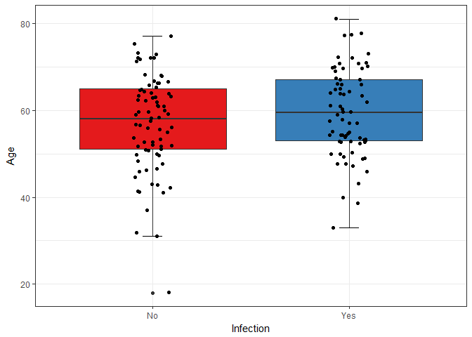

```r
ggplot(df, aes(y = age, x = infection, fill = infection)) +
  stat_boxplot(geom = "errorbar", width = 0.1) +
  geom_boxplot() +
  geom_jitter(width = .1) +
  theme_bw() +
  scale_fill_brewer("infection", palette = "Set1") +
  labs(x = "Infection", y = "Age") +
  theme(legend.position = "none")
```

> `geom_boxplot()` already shows points but only for outliers. However adding `geom_jitter()` we’re already showing the points. We can remove the duplicate outliers by adding the `outlier.shape = NA` argument within the boxplot geom

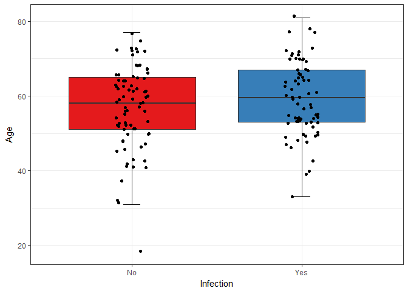

```r
ggplot(df, aes(y = age, x = infection, fill = infection)) +
  stat_boxplot(geom = "errorbar", width = 0.1) +
  geom_boxplot(outlier.shape = NA) +
  geom_jitter(width = .1) +
  theme_bw() +
  scale_fill_brewer("infection", palette = "Set1") +
  labs(x = "Infection", y = "Age") +
  theme(legend.position = "none")
```

## 7.9 Mapping a color to a specific layer

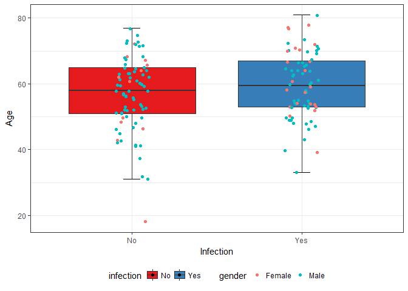

```r
ggplot(df, aes(y = age, x = infection, fill = infection)) +
  stat_boxplot(geom = "errorbar", width = 0.1) +
  geom_boxplot(outlier.shape = NA) +
  geom_jitter(width = .1, aes(color = gender)) +
  theme_bw() +
  scale_fill_brewer("infection", palette = "Set1") +
  labs(x = "Infection", y = "Age") +
  theme(legend.position = 'bottom')
```

> Now that we have gender visualized, what if we want to change the colors for the scatter layer? We can do this by using the `scale_color_brewer()`. Note ‘color’ for the ‘color’ argument and ‘fill’ for the ’fill` argument.

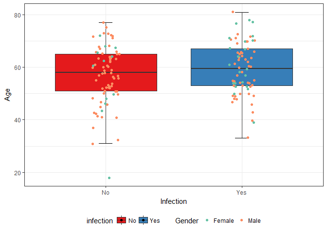

```r
ggplot(df, aes(y = age, x = infection, fill = infection)) +
  stat_boxplot(geom = "errorbar", width = 0.1) +
  geom_boxplot(outlier.shape = NA) +
  geom_jitter(width = .1, aes(color = gender)) +
  theme_bw() +
  scale_fill_brewer("infection", palette = "Set1") +
  labs(x = "Infection", y = "Age") +
  theme(legend.position = 'bottom') +
  scale_color_brewer('Gender', palette = "Set2")
```

# 8 My First Barplot

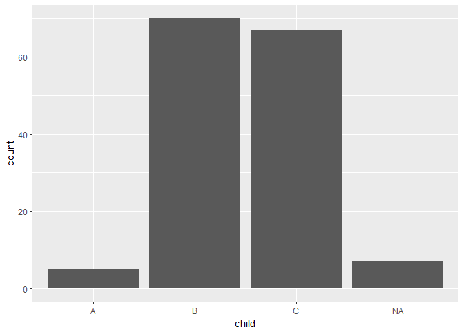

```r
ggplot(df, aes(x = child)) + geom_bar()
```

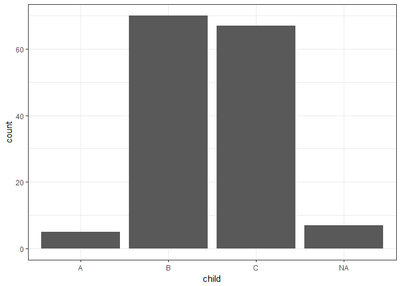

```r
ggplot(df, aes(x = child)) + geom_bar() + theme_bw()
```

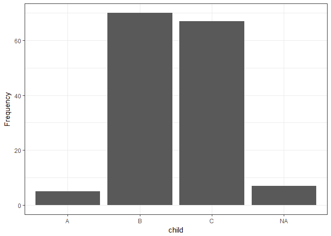

```r
ggplot(df, aes(x = child)) + theme_bw() + geom_bar() +
  labs(y = "Frequency")
```

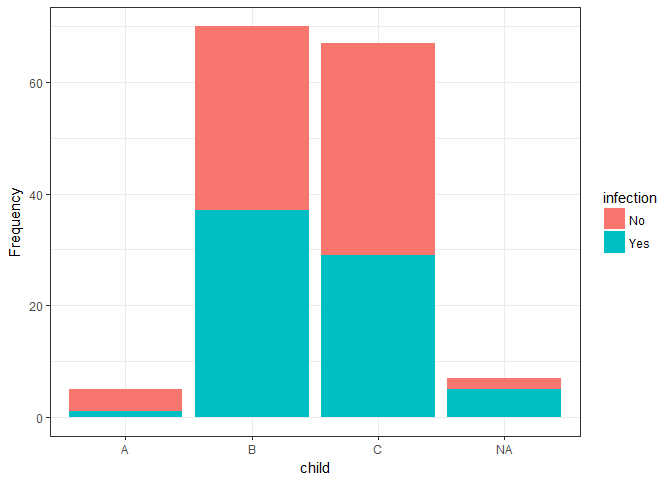

```r
ggplot(df, aes(x = child, fill = infection)) + theme_bw() + geom_bar() +
  labs(y = "Frequency")
```

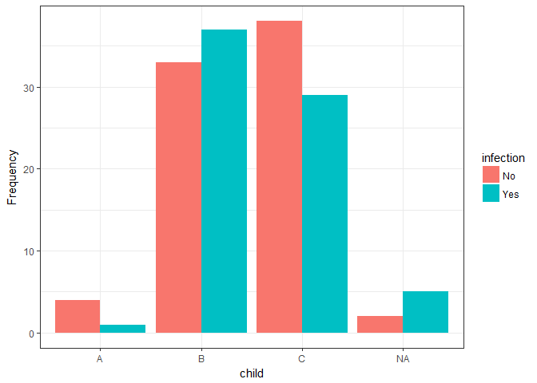

```r
ggplot(df, aes(x = child, fill = infection)) +
  theme_bw() +
  geom_bar(position = position_dodge()) +
  labs(y = "Frequency")
```

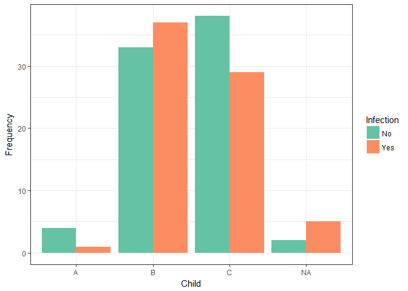

```r
ggplot(df, aes(x = child, fill = infection)) +
  theme_bw() +
  geom_bar(position = position_dodge()) +
  labs(y = "Frequency", x = 'Child') +
  scale_fill_brewer('Infection', palette = 'Set2')
```

# 9 References

https://www.tidyverse.org/packages/

https://www.rstudio.com/resources/cheatsheets/